# German Credit Data로 Scorecard 만들기

## 1. German Credit Data의 load

- 파일 이름이 `german.RData`인 R portable 파일을 loading 함

```r
load("d:/SDSEDU/german.RData")
```

## 2. 함수 `rpart`를 활용한 중요변수 파악 및 classing

### 2.1 중요변수 파악

- rpart를 사용하여 german 데이터에서
- 타겟변수 good.bad를 설명하여 주요 변수들을 quick하게 파악함

```r
library(rpart)
# Information, 즉 entropy 기준 split 옵션 선택
german.rpart <- rpart(good.bad ~ ., parm = list(split = "information"), data = german)
german.rpart
```

```
## n= 1000
##
## node), split, n, loss, yval, (yprob)
##       * denotes terminal node
##
##   1) root 1000 300 good (0.3000 0.7000)
##     2) checking=1,2 543 240 good (0.4420 0.5580)
##       4) duration>=22.5 237 103 bad (0.5654 0.4346)
##         8) savings=1,2,3 196  74 bad (0.6224 0.3776)
##          16) duration>=47.5 36   5 bad (0.8611 0.1389) *
##          17) duration< 47.5 160  69 bad (0.5687 0.4313)
##            34) purpose=0,2,3,5,6,9,X 137  52 bad (0.6204 0.3796) *
##            35) purpose=1 23   6 good (0.2609 0.7391) *
##         9) savings=4,5 41  12 good (0.2927 0.7073) *
##       5) duration< 22.5 306 106 good (0.3464 0.6536)
##        10) history=0,1 28   7 bad (0.7500 0.2500) *
##        11) history=2,3,4 278  85 good (0.3058 0.6942)
##          22) duration>=11.5 198  71 good (0.3586 0.6414)
##            44) amount< 1388 73  36 bad (0.5068 0.4932)
##              88) property=3,4 23   4 bad (0.8261 0.1739) *
##              89) property=1,2 50  18 good (0.3600 0.6400)
##               178) purpose=0,4,6,8 21   8 bad (0.6190 0.3810) *
##               179) purpose=2,3,9 29   5 good (0.1724 0.8276) *
##            45) amount>=1388 125  34 good (0.2720 0.7280) *
##          23) duration< 11.5 80  14 good (0.1750 0.8250) *
##     3) checking=3,4 457  60 good (0.1313 0.8687) *
```

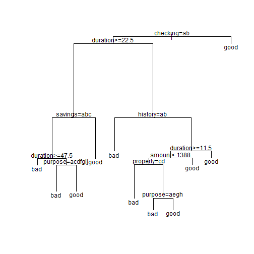

```r
plot(german.rpart)
text(german.rpart)
```

```r
summary(german.rpart)
```

```
## Call:
## rpart(formula = good.bad ~ ., data = german, parms = list(split = "information"))
##   n= 1000
##
##        CP nsplit rel error xerror    xstd
## 1 0.05167      0    1.0000   1.00 0.04830
## 2 0.04667      3    0.8400   1.06 0.04909
## 3 0.01833      4    0.7933   0.91 0.04696
## 4 0.01667      6    0.7567   0.91 0.04696
## 5 0.01000     10    0.6900   0.87 0.04629
##
## Variable importance
## checking duration  purpose  history  savings   amount property      age
##       35       14       11       11       10        7        6        2
## employed  housing
##        1        1
##
## Node number 1: 1000 observations,    complexity param=0.05167
##   predicted class=good  expected loss=0.3  P(node) =1
##     class counts:   300   700
##    probabilities: 0.300 0.700
##   left son=2 (543 obs) right son=3 (457 obs)
##   Primary splits:
##       checking splits as  LLRR,       improve=60.45, (0 missing)
##       savings  splits as  LLRRR,      improve=18.93, (0 missing)
##       history  splits as  LLRRR,      improve=18.44, (0 missing)
##       duration < 15.5  to the right,  improve=16.17, (0 missing)
##       purpose  splits as  LRLRLLLRLL, improve=14.59, (0 missing)
##   Surrogate splits:
##       savings  splits as  LLRRR,      agree=0.611, adj=0.149, (0 split)
##       history  splits as  LLLLR,      agree=0.592, adj=0.107, (0 split)
##       purpose  splits as  LRLRLLLLLL, agree=0.574, adj=0.068, (0 split)
##       employed splits as  LLLLR,      agree=0.554, adj=0.024, (0 split)
##       age      < 30.5  to the left,   agree=0.554, adj=0.024, (0 split)
##
## Node number 2: 543 observations,    complexity param=0.05167
##   predicted class=good  expected loss=0.442  P(node) =0.543
##     class counts:   240   303
##    probabilities: 0.442 0.558
##   left son=4 (237 obs) right son=5 (306 obs)
```

[output cut: 175 more lines]

```
##       savings  splits as  RRRLL,     agree=0.64, adj=0.143, (0 split)
##       amount   < 1162  to the right, agree=0.62, adj=0.095, (0 split)
##       employed splits as  LRRRR,     agree=0.62, adj=0.095, (0 split)
##       coapp    splits as  LRR,       agree=0.62, adj=0.095, (0 split)
##       age      < 41.5  to the right, agree=0.62, adj=0.095, (0 split)
##
## Node number 178: 21 observations
##   predicted class=bad   expected loss=0.381  P(node) =0.021
##     class counts:    13     8
##    probabilities: 0.619 0.381
##
## Node number 179: 29 observations
##   predicted class=good  expected loss=0.1724  P(node) =0.029
##     class counts:     5    24
##    probabilities: 0.172 0.828
```

#### 2.2 연속형 (`numeric`) 변수의 classing

```r
gr.duration <- rpart(good.bad ~ duration, parm = list(split = "information"),
    data = german)
gr.duration
```

```
## n= 1000
##
## node), split, n, loss, yval, (yprob)
##       * denotes terminal node
##
## 1) root 1000 300 good (0.3000 0.7000)
##   2) duration>=15.5 569 211 good (0.3708 0.6292)
##     4) duration>=43.5 70  30 bad (0.5714 0.4286) *
##     5) duration< 43.5 499 171 good (0.3427 0.6573) *
##   3) duration< 15.5 431  89 good (0.2065 0.7935) *
```

## 3. 패키지 `partykit`을 활용한 예쁜 나무 모형 그리기

```r
library(partykit)
german.party <- as.party(german.rpart)
print(german.party)
```

```
##
## Model formula:
## good.bad ~ checking + duration + history + purpose + amount +
##     savings + employed + installp + marital + coapp + resident +
##     property + age + other + housing + existcr + job + depends +
##     telephon + foreign
##
## Fitted party:
## [1] root
## |   [2] checking in 1, 2
## |   |   [3] duration >= 22.5
## |   |   |   [4] savings in 1, 2, 3
## |   |   |   |   [5] duration >= 47.5: bad (n = 36, err = 14%)
## |   |   |   |   [6] duration < 47.5
## |   |   |   |   |   [7] purpose in 0, 2, 3, 5, 6, 9, X: bad (n = 137, err = 38%)
## |   |   |   |   |   [8] purpose in 1: good (n = 23, err = 26%)
## |   |   |   [9] savings in 4, 5: good (n = 41, err = 29%)
## |   |   [10] duration < 22.5
## |   |   |   [11] history in 0, 1: bad (n = 28, err = 25%)
## |   |   |   [12] history in 2, 3, 4
## |   |   |   |   [13] duration >= 11.5
## |   |   |   |   |   [14] amount < 1387.5
## |   |   |   |   |   |   [15] property in 3, 4: bad (n = 23, err = 17%)
## |   |   |   |   |   |   [16] property in 1, 2
## |   |   |   |   |   |   |   [17] purpose in 0, 4, 6, 8: bad (n = 21, err = 38%)
## |   |   |   |   |   |   |   [18] purpose in 2, 3, 9: good (n = 29, err = 17%)
## |   |   |   |   |   [19] amount >= 1387.5: good (n = 125, err = 27%)
## |   |   |   |   [20] duration < 11.5: good (n = 80, err = 18%)
## |   [21] checking in 3, 4: good (n = 457, err = 13%)
##
## Number of inner nodes:    10
## Number of terminal nodes: 11
```

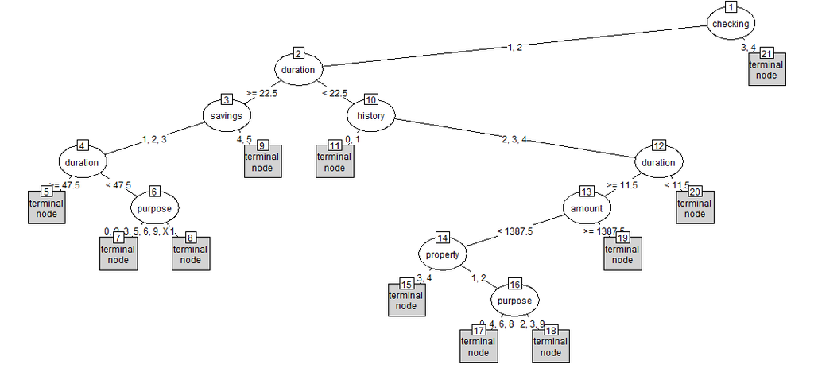

```r
plot(german.party, type = "simple")
```

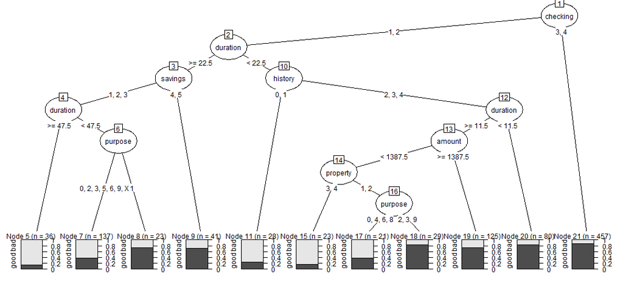

```r
plot(german.party, type = "extended")
```

```r
gr.duration.party <- as.party(gr.duration)
print(gr.duration.party)
```

```
##
## Model formula:
## good.bad ~ duration
##
## Fitted party:
## [1] root
## |   [2] duration >= 15.5
## |   |   [3] duration >= 43.5: bad (n = 70, err = 43%)
## |   |   [4] duration < 43.5: good (n = 499, err = 34%)
## |   [5] duration < 15.5: good (n = 431, err = 21%)
##
## Number of inner nodes:    2
## Number of terminal nodes: 3
```

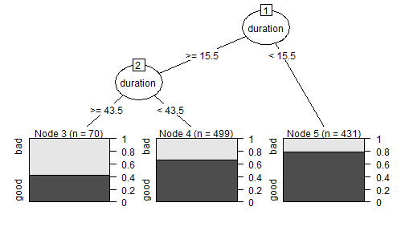

```r
plot(gr.duration.party, type = "extended")
```

## 4. `glm` 함수를 이용한 Logistic regresion

- `glm` = generalized linear model

```r
logit.german <- glm(good.bad ~ ., data = german, family = binomial())
summary(logit.german)
```

```
##
## Call:
## glm(formula = good.bad ~ ., family = binomial(), data = german)
##
## Deviance Residuals:
##    Min      1Q  Median      3Q     Max
## -2.612  -0.710   0.375   0.699   2.341
##
## Coefficients:
##              Estimate Std. Error z value Pr(>|z|)
## (Intercept) -4.01e-01   1.08e+00   -0.37  0.71187
## checking2    3.75e-01   2.18e-01    1.72  0.08540 .
## checking3    9.66e-01   3.69e-01    2.62  0.00890 **
## checking4    1.71e+00   2.32e-01    7.37  1.7e-13 ***
## duration    -2.79e-02   9.30e-03   -3.00  0.00272 **
## history1    -1.43e-01   5.49e-01   -0.26  0.79392
## history2     5.86e-01   4.30e-01    1.36  0.17335
## history3     8.53e-01   4.72e-01    1.81  0.07047 .
## history4     1.44e+00   4.40e-01    3.26  0.00110 **
## purpose1     1.67e+00   3.74e-01    4.45  8.5e-06 ***
## purpose2     7.92e-01   2.61e-01    3.03  0.00242 **
## purpose3     8.92e-01   2.47e-01    3.61  0.00031 ***
## purpose4     5.23e-01   7.62e-01    0.69  0.49283
## purpose5     2.16e-01   5.50e-01    0.39  0.69400
## purpose6    -3.63e-02   3.96e-01   -0.09  0.92708
## purpose8     2.06e+00   1.21e+00    1.70  0.08930 .
## purpose9     7.40e-01   3.34e-01    2.22  0.02667 *
## purposeX     1.49e+00   7.76e-01    1.92  0.05516 .
## amount      -1.28e-04   4.44e-05   -2.89  0.00389 **
## savings2     3.58e-01   2.86e-01    1.25  0.21113
## savings3     3.76e-01   4.01e-01    0.94  0.34848
## savings4     1.34e+00   5.25e-01    2.55  0.01073 *
## savings5     9.47e-01   2.62e-01    3.61  0.00031 ***
## employed2    6.69e-02   4.27e-01    0.16  0.87548
## employed3    1.83e-01   4.11e-01    0.45  0.65605
## employed4    8.31e-01   4.45e-01    1.87  0.06211 .
## employed5    2.77e-01   4.13e-01    0.67  0.50341
## installp    -3.30e-01   8.83e-02   -3.74  0.00018 ***
## marital2     2.75e-01   3.87e-01    0.71  0.47604
## marital3     8.16e-01   3.80e-01    2.15  0.03172 *
```

[output cut: 14 more lines]

```
## job3        -5.55e-01   6.55e-01   -0.85  0.39701
## job4        -4.79e-01   6.62e-01   -0.72  0.46909
## depends     -2.65e-01   2.49e-01   -1.06  0.28825
## telephon2    3.00e-01   2.01e-01    1.49  0.13606
## foreign2     1.39e+00   6.26e-01    2.22  0.02609 *
## ---
## Signif. codes:  0 '***' 0.001 '**' 0.01 '*' 0.05 '.' 0.1 ' ' 1
##
## (Dispersion parameter for binomial family taken to be 1)
##
##     Null deviance: 1221.73  on 999  degrees of freedom
## Residual deviance:  895.82  on 951  degrees of freedom
## AIC: 993.8
##
## Number of Fisher Scoring iterations: 5
```

- `glm` 함수는 data frame 내에 factor변수가 있으면 자동으로 dummay 변수로 변환하여 모델링함
- 본 과정에서는 분석과정에서 인위적으로 만든 dummay 변수 활용을 권장함

## 5. Training vs. Validation 데이터

- 본 과정에서 1000개 관측치로 구성된 german 데이터를 tranin: validation=7:3 으로 나눈 index를 생성함
- 즉,
  - **`tr.index`** : 전채 데이터 중 70%를 샘플링한 tranin index
  - **`german.tr`** : traning data
  - **`german.val`** : validation data

```r
tr.index <- sample(1:1000, round(1000 * 0.7))
german.tr <- german[tr.index, ]
german.val <- german[-tr.index, ]
```

## 6. `ggplot2` 를 활용한 데이터 탐색

- Train과 vaidation 데이터를 target variable인 good.bad 분포 관점에서 유사함을 살펴봄

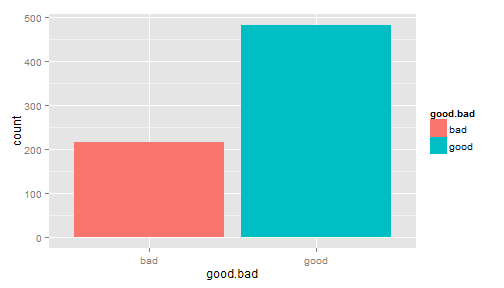

```r
library(ggplot2)

# 함수 qplot은 ggplot 명령어의 quick plot 버젼임
qplot(good.bad, data = german.tr, geom = "bar", fill = good.bad)
```

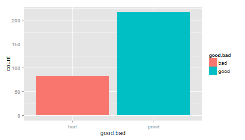

```r
qplot(good.bad, data = german.val, geom = "bar", fill = good.bad)
```

### 6.1 `checking` 변수에 대한 Good vs. Bad의 비교

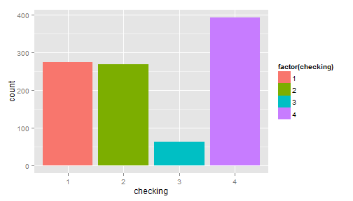

```r
ggplot(german, aes(checking, fill = factor(checking))) + geom_bar()
```

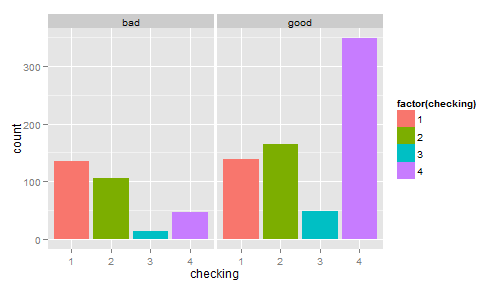

```r
ggplot(german, aes(checking, fill = factor(checking))) + geom_bar() + facet_grid(. ~
    good.bad)
```

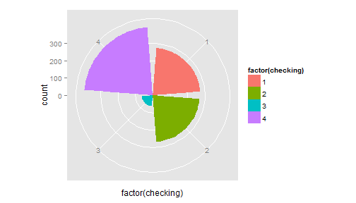

```r
ggplot(german, aes(factor(checking), fill = factor(checking))) + geom_bar() +
    coord_polar()
```

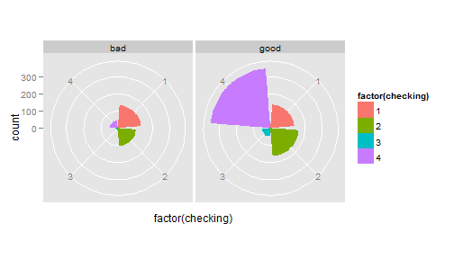

```r
ggplot(german, aes(factor(checking), fill = factor(checking))) + geom_bar() +
    coord_polar() + facet_grid(. ~ good.bad)
```

```r
gr.checking <- as.data.frame(table(german$good.bad, german$checking))
gr.checking
```

```
##   Var1 Var2 Freq
## 1  bad    1  135
## 2 good    1  139
## 3  bad    2  105
## 4 good    2  164
## 5  bad    3   14
## 6 good    3   49
## 7  bad    4   46
## 8 good    4  348
```

```r
library(plyr)
gr.checking.mutate <- ddply(gr.checking, .(Var1), mutate, freq.sum = sum(Freq))
gr.checking.mutate
```

```
##   Var1 Var2 Freq freq.sum
## 1  bad    1  135      300
## 2  bad    2  105      300
## 3  bad    3   14      300
## 4  bad    4   46      300
## 5 good    1  139      700
## 6 good    2  164      700
## 7 good    3   49      700
## 8 good    4  348      700
```

```r
gr.checking.freq <- ddply(gr.checking.mutate, .(Var1, Var2), summarise, freq.percent = Freq/freq.sum)
gr.checking.freq
```

```
##   Var1 Var2 freq.percent
## 1  bad    1      0.45000
## 2  bad    2      0.35000
## 3  bad    3      0.04667
## 4  bad    4      0.15333
## 5 good    1      0.19857
## 6 good    2      0.23429
## 7 good    3      0.07000
## 8 good    4      0.49714
```

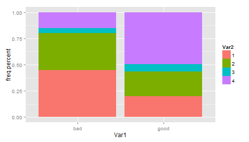

```r
ggplot(gr.checking.freq, aes(Var1, freq.percent)) + geom_bar(aes(fill = Var2),
    stat = "identity")
```

### 6.2 box plot을 활용한 분포 비교

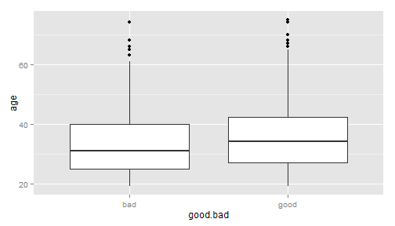

```r
p <- ggplot(german, aes(good.bad, age))
p + geom_boxplot()
```

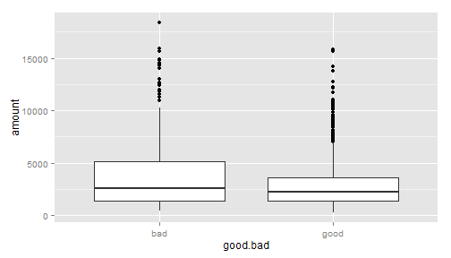

```r
p <- ggplot(german, aes(good.bad, amount))
p + geom_boxplot()
```

### 6.3 `amount`에 대한 density plot

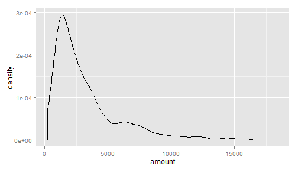

```r
pp <- ggplot(german, aes(amount))
pp + geom_density()
```

- `amount` 변수의 분포가 우측으로 길게 꼬리가 늘어져 있어 함수 log를 취해 (가능하면) 좌우대칭 분포로 변환함

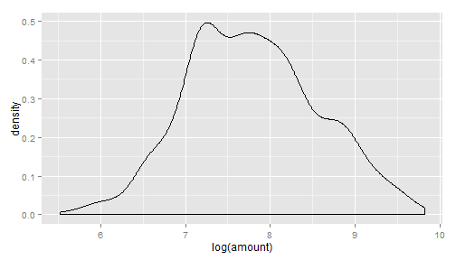

```r
logpp <- ggplot(german, aes(log(amount)))
logpp + geom_density()
```

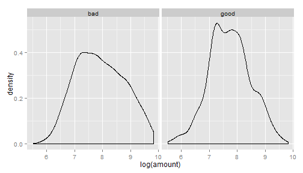

```r
logpp + geom_density() + facet_grid(. ~ good.bad)
```

## 7. Classing

- 각 변수별로 classing을 시도함
- `age`의 경우, `ggplot` 결과와 같이 `good.bad` 예측에 도움이 되지 않아 `rpart`에서 split이 일어나지 않음

```r
rpart(good.bad ~ age, german.tr, parm = list(split = "information"))
```

```
## n= 700
##
## node), split, n, loss, yval, (yprob)
##       * denotes terminal node
##
## 1) root 700 217 good (0.3100 0.6900) *
```

```r
rpart(good.bad ~ amount, german.tr, parm = list(split = "information"))
```

```
## n= 700
##
## node), split, n, loss, yval, (yprob)
##       * denotes terminal node
##
##  1) root 700 217 good (0.3100 0.6900)
##    2) amount>=3910 189  88 good (0.4656 0.5344)
##      4) amount>=1.131e+04 20   5 bad (0.7500 0.2500) *
##      5) amount< 1.131e+04 169  73 good (0.4320 0.5680)
##       10) amount< 4464 33  15 bad (0.5455 0.4545)
##         20) amount>=4050 18   6 bad (0.6667 0.3333) *
##         21) amount< 4050 15   6 good (0.4000 0.6000) *
##       11) amount>=4464 136  55 good (0.4044 0.5956) *
##    3) amount< 3910 511 129 good (0.2524 0.7476) *
```

```r
rpart(good.bad ~ amount, german.tr, control = rpart.control(minsplit = 5), parm = list(split = "information"))
```

```
## n= 700
##
## node), split, n, loss, yval, (yprob)
##       * denotes terminal node
##
##  1) root 700 217 good (0.3100 0.6900)
##    2) amount>=3910 189  88 good (0.4656 0.5344)
##      4) amount>=1.131e+04 20   5 bad (0.7500 0.2500) *
##      5) amount< 1.131e+04 169  73 good (0.4320 0.5680)
##       10) amount< 3935 3   0 bad (1.0000 0.0000) *
##       11) amount>=3935 166  70 good (0.4217 0.5783) *
##    3) amount< 3910 511 129 good (0.2524 0.7476) *
```

## 8. dummay variable 만들기

- 예를 들어, `saving` 변수(levels=1,2,3,4,5)에 대하여 level=1,2를 하나로 grouping하여 총 4개의 level에 대한 dummay 변수를 만들 경우, 총 3개의 dummay 변수를 만들어야 함

```r
german.savings <- german$savings
savings.d1 <- (german.savings == "1" | german.savings == "2") * 1
savings.d2 <- (german.savings == "3") * 1
savings.d3 <- (german.savings == "4") * 1
```

- `cbind`를 활용하여 `matrix`를 구성함
- 이때 `matrix`는 `savings.d1`, `savings.d2`, `savings.d3`라는 변수이름을 보유함

```r
savings.dummy <- cbind(savings.d1, savings.d2, savings.d3)
head(savings.dummy)
```

```
##      savings.d1 savings.d2 savings.d3
## [1,]          0          0          0
## [2,]          1          0          0
## [3,]          1          0          0
## [4,]          1          0          0
## [5,]          1          0          0
## [6,]          0          0          0
```

- 기존의 `german`이라는 data frame과 dummy variable로 구성된 matrix를 결합하여 새로운 german.cp라는 data frame을 구성함

```r
german.cp <- cbind(german, savings.dummy)
```

- Dummay 변수에 대하여 traning 데이터를 활용하여 로지스틱 회귀모형을 적용함

```r
logit.german.cp <- glm(good.bad ~ savings.d1 + savings.d2 + savings.d3, data = german.cp[tr.index,
    ], family = binomial())
logit.german.cp
```

```
##
## Call:  glm(formula = good.bad ~ savings.d1 + savings.d2 + savings.d3,
##     family = binomial(), data = german.cp[tr.index, ])
##
## Coefficients:
## (Intercept)   savings.d1   savings.d2   savings.d3
##      1.4271      -0.8604      -0.0101       0.6206
##
## Degrees of Freedom: 699 Total (i.e. Null);  696 Residual
## Null Deviance:       867
## Residual Deviance: 842   AIC: 850
```

- Validation 데이터에 대하여 socring을 구하고
- Good vs. bad 정보를 바인딩함

```r
scr.val <- predict(logit.german.cp, newdata = german.cp[-tr.index, ])
data.frame(log.odds = scr.val, good.bad = german.cp[-tr.index, "good.bad"])
```

```
##     log.odds good.bad
## 10    0.5667      bad
## 11    0.5667      bad
## 12    0.5667      bad
## 20    1.4171     good
## 21    0.5667     good
## 25    1.4271     good
## 28    2.0477     good
## 29    0.5667     good
## 30    0.5667      bad
## 31    2.0477     good
## 34    1.4271     good
## 40    0.5667     good
## 41    1.4171     good
## 42    1.4171     good
```

[output cut: 286 more lines]

```r
cbind(log.odds = scr.val, good.bad = german.cp[-tr.index, "good.bad"])
```

```
##     log.odds good.bad
## 10    0.5667        1
## 11    0.5667        1
## 12    0.5667        1
## 20    1.4171        2
## 21    0.5667        2
## 25    1.4271        2
## 28    2.0477        2
## 29    0.5667        2
## 30    0.5667        1
## 31    2.0477        2
## 34    1.4271        2
## 40    0.5667        2
## 41    1.4171        2
## 42    1.4171        2
```

[output cut: 286 more lines]

## 9. `riv` 패키지를 이용한 auto binning

```r
library(devtools)
# install_github('riv','tomasgreif')
library(woe)
str(german_data)
```

```
## 'data.frame':    1000 obs. of  21 variables:
##  $ ca_status                : Factor w/ 4 levels "(;0DM)","<0DM;200DM)",..: 1 2 4 1 1 4 4 2 4 2 ...
##  $ duration                 : int  6 48 12 42 24 36 24 36 12 30 ...
##  $ credit_history           : Factor w/ 5 levels "no credits","paid off",..: 5 3 5 3 4 3 3 3 3 5 ...
##  $ purpose                  : Factor w/ 10 levels "car (new)","car (used)",..: 4 4 7 3 1 7 3 2 4 1 ...
##  $ credit_amount            : int  1169 5951 2096 7882 4870 9055 2835 6948 3059 5234 ...
##  $ savings                  : Factor w/ 5 levels "(;100DM)","<100;500)",..: 5 1 1 1 1 5 3 1 4 1 ...
##  $ present_employment_since : Factor w/ 5 levels "unemployed","(;1)",..: 5 3 4 4 3 3 5 3 4 1 ...
##  $ installment_rate_income  : int  4 2 2 2 3 2 3 2 2 4 ...
##  $ status_sex               : Factor w/ 5 levels "male:div./sep.",..: 3 2 3 3 3 3 3 3 1 4 ...
##  $ other_debtors            : Factor w/ 3 levels "none","co-applicant",..: 1 1 1 3 1 1 1 1 1 1 ...
##  $ present_residence_since  : int  4 2 3 4 4 4 4 2 4 2 ...
##  $ property                 : Factor w/ 4 levels "real estate",..: 1 1 1 2 4 4 2 3 1 3 ...
##  $ age                      : int  67 22 49 45 53 35 53 35 61 28 ...
##  $ other_installment        : Factor w/ 3 levels "bank","stores",..: 3 3 3 3 3 3 3 3 3 3 ...
##  $ housing                  : Factor w/ 3 levels "rent","own","for free": 2 2 2 3 3 3 2 1 2 2 ...
##  $ existing_credits         : int  2 1 1 1 2 1 1 1 1 2 ...
##  $ job                      : Factor w/ 4 levels "unemp./unsk. nonr.",..: 3 3 2 3 3 2 3 4 2 4 ...
##  $ liable_maintenance_people: int  1 1 2 2 2 2 1 1 1 1 ...
##  $ telephone                : Factor w/ 2 levels "none","yes": 2 1 1 1 1 2 1 2 1 1 ...
##  $ foreign_worker           : Factor w/ 2 levels "yes","no": 1 1 1 1 1 1 1 1 1 1 ...
##  $ gb                       : Factor w/ 2 levels "bad","good": 2 1 2 2 1 2 2 2 2 1 ...
```

```r
iv.mult(german_data, "gb", TRUE)
```

```
## Information Value 0.67
```

```
## Information Value 0.26
## Information Value 0.29
## Information Value 0.17
## Information Value 0.21
## Information Value 0.2
## Information Value 0.09
## Information Value 0.02
```

```
## Information Value NaN
## Information Value 0.03
## Information Value 0
## Information Value 0.11
## Information Value 0.13
## Information Value 0.06
## Information Value 0.08
## Information Value 0.01
## Information Value 0.01
## Information Value 0
## Information Value 0.01
## Information Value 0.04
```

```
##                     Variable InformationValue Bins ZeroBins    Strength
## 1                  ca_status         0.666012    4        0 Very strong
## 2             credit_history         0.293234    5        0      Strong
## 3                   duration         0.259147    5        0      Strong
## 4              credit_amount         0.207970    5        0      Strong
## 5                    savings         0.196010    5        0     Average
## 6                    purpose         0.169195   10        0     Average
## 7                        age         0.125211    5        0     Average
## 8                   property         0.112638    4        0     Average
## 9   present_employment_since         0.086434    5        0        Weak
## 10                   housing         0.083293    3        0        Weak
## 11         other_installment         0.057615    3        0        Weak
## 12                status_sex         0.044671    5        1        Weak
## 13            foreign_worker         0.043877    2        0        Weak
## 14             other_debtors         0.032019    3        0        Weak
## 15   installment_rate_income         0.023859    2        0        Weak
## 16          existing_credits         0.010084    2        0   Wery weak
## 17                       job         0.008763    4        0   Wery weak
## 18                 telephone         0.006378    2        0   Wery weak
## 19 liable_maintenance_people         0.000000    1        0   Wery weak
## 20   present_residence_since         0.000000    1        0   Wery weak
```

```
## Information Value 0.67
## Information Value 0.26
## Information Value 0.29
## Information Value 0.17
## Information Value 0.21
## Information Value 0.2
## Information Value 0.09
## Information Value 0.02
```

```
## Information Value NaN
## Information Value 0.03
## Information Value 0
## Information Value 0.11
## Information Value 0.13
## Information Value 0.06
## Information Value 0.08
## Information Value 0.01
## Information Value 0.01
## Information Value 0
## Information Value 0.01
## Information Value 0.04
```

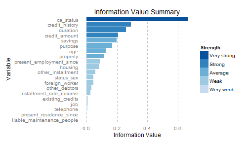

```r
iv.plot.summary(iv.mult(german_data, "gb", TRUE))
```

```r
options(digits = 2)
iv.mult(german_data, "gb", vars = c("housing", "duration"))
```

```
## Information Value 0.08
## Information Value 0.26
```

```
## [[1]]
##   variable    class outcome_0 outcome_1 pct_0 pct_1 odds   woe   miv
## 1  housing     rent       109        70 0.156  0.23 0.67 -0.40 0.031
## 2  housing      own       527       186 0.753  0.62 1.21  0.19 0.026
## 3  housing for free        64        44 0.091  0.15 0.62 -0.47 0.026
##
## [[2]]
##   variable       class outcome_0 outcome_1 pct_0 pct_1 odds    woe     miv
## 1 duration     (;11.5)       153        27  0.22  0.09 2.43  0.887 1.1e-01
## 2 duration <11.5;15.5)       189        62  0.27  0.21 1.31  0.267 1.7e-02
## 3 duration   <15.5;19)        72        43  0.10  0.14 0.72 -0.332 1.3e-02
## 4 duration   <19;34.5)       198        86  0.28  0.29 0.99 -0.013 5.1e-05
## 5 duration     <34.5;)        88        82  0.13  0.27 0.46 -0.777 1.1e-01
##                                                                sql
## 1                      when duration < 11.5 then 0.887303195000903
## 2 when duration >= 11.5 AND duration < 15.5 then 0.267314769627347
## 3  when duration >= 15.5 AND duration < 19 then -0.331831857064711
## 4 when duration >= 19 AND duration < 34.5 then -0.0133781259461761
## 5                     when duration >= 34.5 then -0.77668029317325
```

```r
iv.num(german_data, "duration", "gb", rcontrol = rpart.control(cp = 0.02))
```

```
## Information Value 0.14
```

```
##   variable   class outcome_0 outcome_1 pct_0 pct_1 odds   woe   miv
## 1 duration (;34.5)       612       218  0.87  0.73 1.20  0.18 0.027
## 2 duration <34.5;)        88        82  0.13  0.27 0.46 -0.78 0.115
##                                            sql
## 1  when duration < 34.5 then 0.184939359336034
## 2 when duration >= 34.5 then -0.77668029317325
```

```r
iv.num(german_data, "duration", "gb", rcontrol = rpart.control(cp = 0.005))
```

```
## Information Value 0.23
```

```
##   variable       class outcome_0 outcome_1 pct_0 pct_1 odds    woe     miv
## 1 duration     (;11.5)       153        27  0.22  0.09 2.43  0.887 0.11408
## 2 duration <11.5;34.5)       459       191  0.66  0.64 1.03  0.029 0.00056
## 3 duration     <34.5;)        88        82  0.13  0.27 0.46 -0.777 0.11465
##                                                                 sql
## 1                       when duration < 11.5 then 0.887303195000903
## 2 when duration >= 11.5 AND duration < 34.5 then 0.0294789216267116
## 3                      when duration >= 34.5 then -0.77668029317325
```

```r
iv.num(german_data, "duration", "gb", rcontrol = rpart.control(cp = 0.001))
```

```
## Information Value 0.36
```

```
##    variable       class outcome_0 outcome_1 pct_0  pct_1 odds    woe
## 1  duration      (;8.5)        84        10 0.120 0.0333 3.60  1.281
## 2  duration   <8.5;9.5)        35        14 0.050 0.0467 1.07  0.069
## 3  duration  <9.5;11.5)        34         3 0.049 0.0100 4.86  1.580
## 4  duration <11.5;12.5)       130        49 0.186 0.1633 1.14  0.128
## 5  duration <12.5;15.5)        59        13 0.084 0.0433 1.95  0.665
## 6  duration   <15.5;19)        72        43 0.103 0.1433 0.72 -0.332
## 7  duration   <19;20.5)         7         1 0.010 0.0033 3.00  1.099
## 8  duration <20.5;34.5)       191        85 0.273 0.2833 0.96 -0.038
## 9  duration <34.5;37.5)        46        37 0.066 0.1233 0.53 -0.630
## 10 duration <37.5;43.5)        12         5 0.017 0.0167 1.03  0.028
## 11 duration     <43.5;)        30        40 0.043 0.1333 0.32 -1.135
##        miv
## 1  1.1e-01
## 2  2.3e-04
```

[output cut: 21 more lines]